# Analysis ERDF 2014-2020 cycle in Italy

Author

Luisa M. Mimmi

Published

November 1, 2022

## ERDF spending in Italy

This plots show the Italy subset, limited to the ERDF (European Regional Development Fund) taken from the [**ESIF 2014-2020 Finance Implementation Details (99js-gm52)**](https://dev.socrata.com/foundry/cohesiondata.ec.europa.eu/99js-gm52) dataset.

The most important financial variables observed in euro (over time) are:

- `total_amount` = Total decided amount (EU + National allocation), also referred to as *“Total Cost”*
- `total_eligible_cost` = Total amount (EU + National) allocated to the projects (operations) selected, also referred to as *“total eligible cost”* reported by the national and regional programmes to the Commission.
- `total_eligible_expenditure` = Total expenditure eligible for reimbursement, as reported by the beneficiary projects to the programmes. Also referred to as *“total eligible expenditure”*, it is reported by the national and regional programmes to the Commission.

Other qualifying variables are:

- `ccc` = *“Unique identifier”* of each operational programme.
- `to_short` = Short name for the *“thematic objective”*. For example: “Research and Innovation” stands for “Strengthening research, technological development and innovation.
- `priority` = Priority Axis: the investment pillars in the programme. Unfortunately, since there is no harmonised numbering or naming of Priority Axes, this variable is useless for comparison.
- `category_of_region` = The three main categories of region are: *“less developed”*, *“transition”*, and *“more developed”*.

## ERDF by region category

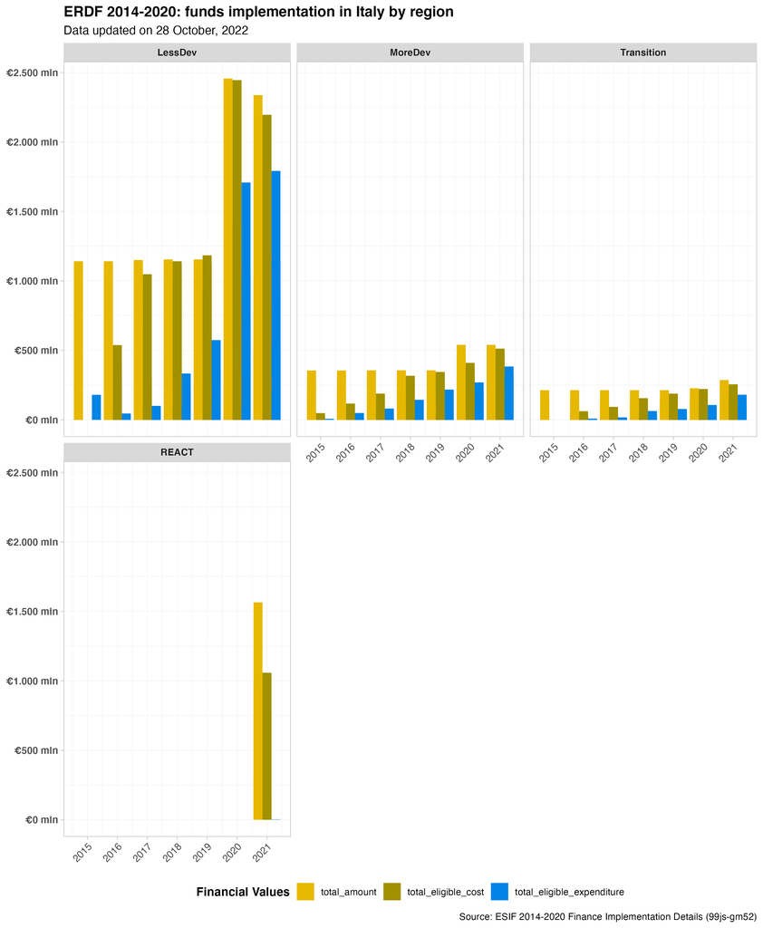

Figure 1: ERDF by region category

## ERDF by theme category

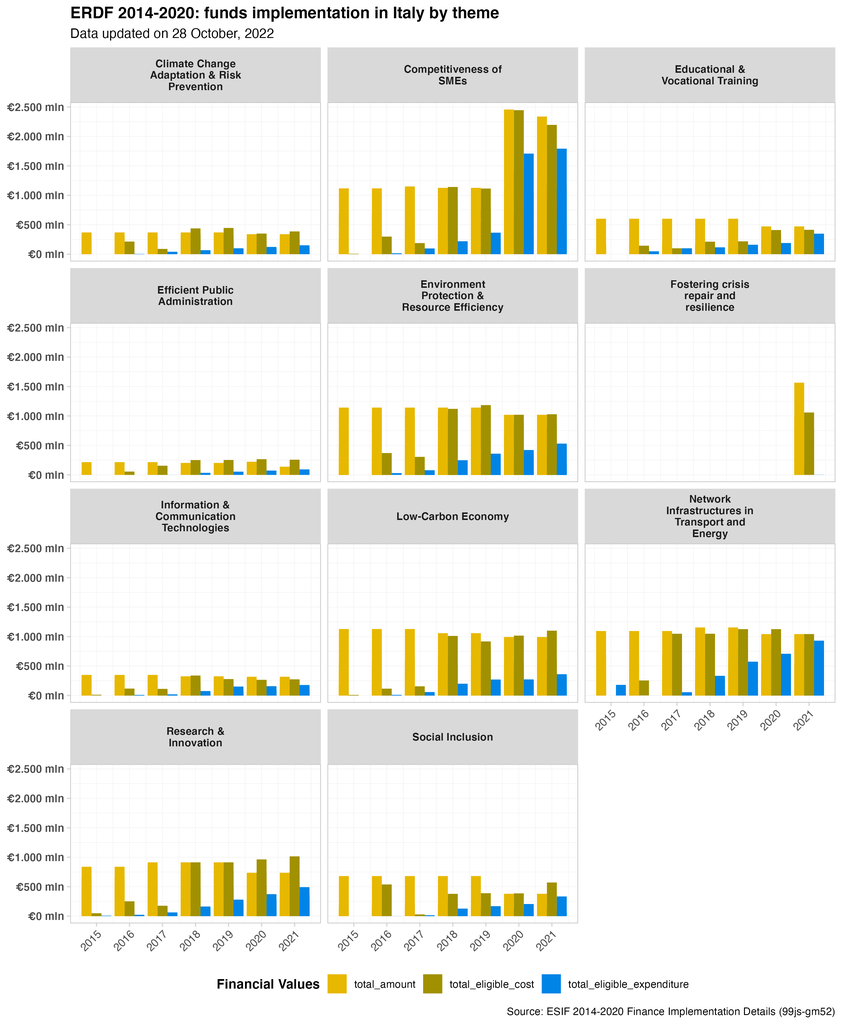

Figure 2: ERDF by theme category

```r
knitr::include_graphics(here::here("fig", "ERDF_eligVspent_theme_time_facet.png"))
```

[figure not shown]

Figure 3: ERDF by theme category

**Note**

In some cases (e.g. Figure 3, in section **Research and Innovation**) the amount decided (`total_eligible_cost)` exceeds the `total_amount` programmed. Why? This happens generally in the last years of a programme period. They do this in order to avoid the risks 1) that some of the decided / selected projects fail to materialise or 2) that irregularities occur over the programme life time which lead to the withdrawal of support to those projects.

## ERDF pent/allocated % spending, by theme & by program

Collapsible table made following [this example](https://glin.github.io/reactable/articles/building-twitter-followers.html)

**Tip**

```r
library(reactable)
t_react2 <- readRDS(file = "fig/t_react2.Rds")
t_react2
```

| Thematic objective | N. & Id of Programs | Title of Programs | Amount Planned | Amount Allocated | Amount Spent | Spent/Allocated at 31/12/2021 |
| --- | --- | --- | --- | --- | --- | --- |
| Environment Protection & Resource Efficiency | 2014IT16RFOP004 | Abruzzo - ERDF | 13.5 | 13.29522806 | 7.86885251 | 0.6 |
| Competitiveness of SMEs | 2014IT16RFOP004 | Abruzzo - ERDF | 110.199226 | 104.87948867 | 62.74436909 | 0.6 |
| Technical Assistance | 2014IT16RFOP004 | Abruzzo - ERDF | 9.32978 | 7.74838556 | 2.76599685 | 0.4 |
| Information & Communication Technologies | 2014IT16RFOP004 | Abruzzo - ERDF | 26 | 26.00052471 | 12.37821412 | 0.5 |
| Multiple Thematic Objectives (ERDF/CF/ESF) | 2014IT16RFOP004 | Abruzzo - ERDF | 32 | 20 | 0.87861931 | 0 |
| Research & Innovation | 2014IT16RFOP004 | Abruzzo - ERDF | 30.180774 | 30.82874102 | 16.51736904 | 0.5 |
| Climate Change Adaptation & Risk Prevention | 2014IT16RFOP004 | Abruzzo - ERDF | 23.43926 | 23.43926 | 10.20530365 | 0.4 |
| Low-Carbon Economy | 2014IT16RFOP004 | Abruzzo - ERDF | 14.56074 | 11.31521758 | 8.84558607 | 0.8 |
| Multiple Thematic Objectives (ERDF/CF/ESF) | 2014IT16RFOP004 | Abruzzo - ERDF | 16.3 | 11.4420114 | 5.80232081 | 0.5 |
| Environment Protection & Resource Efficiency | 2014IT16RFOP022 | Basilicata - ERDF | 73.761277 | 180.31506471 | 42.59496465 | 0.2 |

[output cut: 212 more lines]

# Reference

Using some tools for the first time, I followed this tutorials/examples:

- `Quarto` (see presentation [here](https://rstudio-conf-2022.github.io/get-started-quarto/materials/07-plots-tables.html#/block-layout-arbitrary-content))
- R package `reactable` (see examples [here](https://glin.github.io/reactable/articles/building-twitter-followers.html#finishing-touches))

The code written (in R) to retrieve and clean the data can be found at this [Github repo](https://github.com/Lulliter/plan2implem)